# Customer Fitting Exploration

In this section, we will create some features, that describe customers and test out some models

```r
library(lubridate)
library(gvlma)
library(pastecs)
library(earth)
library(gbm)
library(plyr)

source("R/utils.R")
source("R/RFM.R")
source("R/customerClustering.R")
source("R/modelFitting.R")
source("R/featureScaling.R")
purchases <- loadPurchases()
```

Remove negative values (for easier handling of data for transformations.. etc)

```r
purchases <- purchases %>%
  filter(sales_amount >= 0 | quantity >= 0)
```

## Customer features

We will use RFM values for describing the customers

- Recency: How long ago was last purchase? (days): days_since_last_purchase
- Frequency: How many orders in analysis period?: order_num
- Monetary: What is total $ value of all orders in analysis period?: total_sales
- Breadth: How many different products purchased?: product_num
- Tenure: How long has a customer been with us? (days since first purchase): active_days

### Customer RFM overview

```r
customer_rfm <- calculateRFMs(purchases)
```

```
## Calculating:  r  ... Calculating:  f  ... Calculating:  m  ... Calculating:  b  ... Calculating:  t  ...
```

```r
summary(customer_rfm)
```

```
##   contact_id        days_since_last_purchase   order_num
##  Length:262295      Min.   :  0.0            Min.   :   1.000
##  Class :character   1st Qu.:173.0            1st Qu.:   1.000
##  Mode  :character   Median :385.0            Median :   1.000
##                     Mean   :362.1            Mean   :   1.598
##                     3rd Qu.:544.0            3rd Qu.:   1.000
##                     Max.   :730.0            Max.   :4395.000
##   total_sales         product_num        active_days
##  Min.   :     0.00   Min.   :   1.000   Min.   :  0.00
##  1st Qu.:    36.95   1st Qu.:   1.000   1st Qu.:  0.00
##  Median :    71.05   Median :   1.000   Median :  0.00
##  Mean   :   137.61   Mean   :   1.923   Mean   : 47.37
##  3rd Qu.:   147.76   3rd Qu.:   2.000   3rd Qu.:  0.00
##  Max.   :286134.76   Max.   :2212.000   Max.   :730.00
```

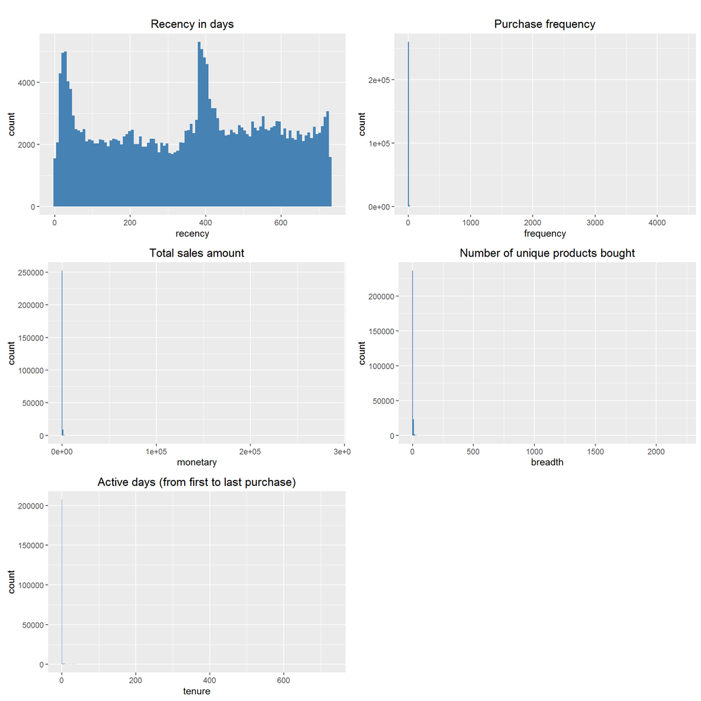

```r
plotRfms(customer_rfm, c(104, 300, 300, 300, 600))
```

### Customer RFMs with next years total sales amount

Since we want to predict next years total revenue, we will add it to the features of a customer, so we will only have the 2012 subset of the purchases for training

```r
purchases_2012 <- purchases %>%
  filter(year(purchase_date) == 2012)
purchases_2013 <- purchases %>%
  filter(year(purchase_date) == 2013)
```

We can see, that except the recency, all the features are severely skewed, but for the first try, we won’t scale, nor transform them

```r
customer_rfm_2012 <- calculateRFMs(purchases_2012)
```

```
## Calculating:  r  ... Calculating:  f  ... Calculating:  m  ... Calculating:  b  ... Calculating:  t  ...
```

```r
customer_rfm_2013 <- calculateRFMs(purchases_2013)
```

```
## Calculating:  r  ... Calculating:  f  ... Calculating:  m  ... Calculating:  b  ... Calculating:  t  ...
```

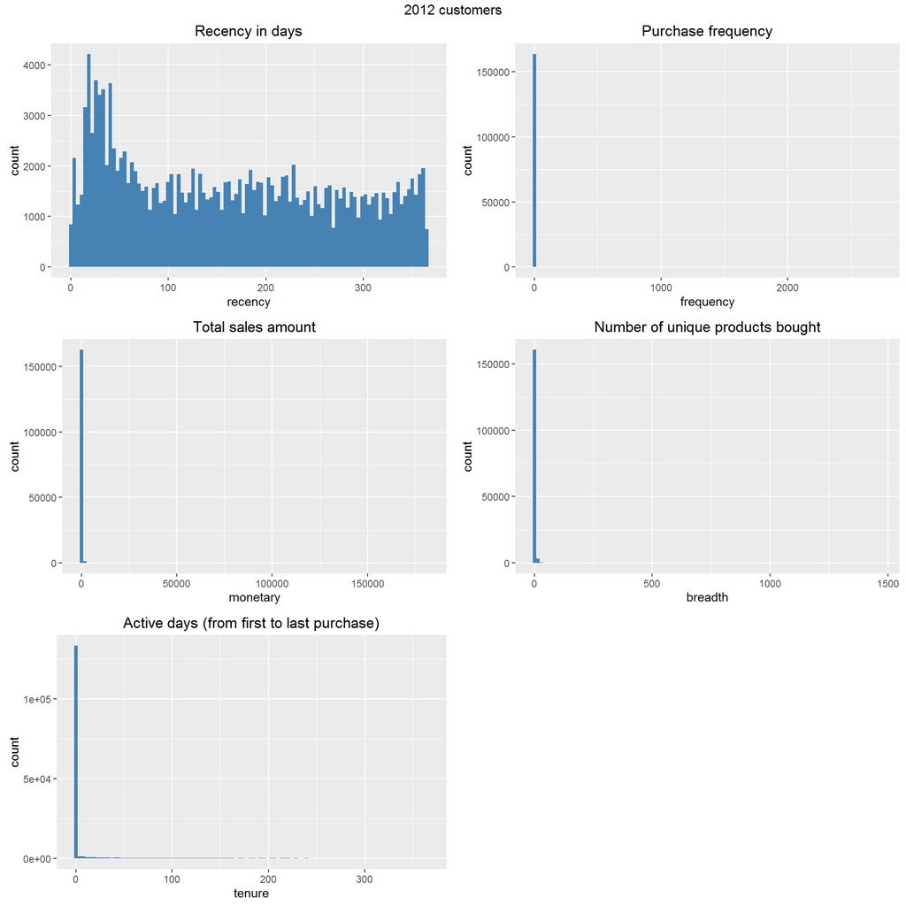

```r
plotRfms(customer_rfm_2012, c(100, 100, 100, 100, 100), title = "2012 customers")
```

We only want to predict the next years revenue and for that we woudn’t need the customers, who didn’t spent any money next year (0 amount does not change the result in any way) on the other hand, how can we know, what the model will predict for these customers, if we didn’t included them in the training set? So we will consider all customers, not just, who stayed active in 2013 too

```r
customer_total_sales_2013 <- calculateTotalSales(purchases_2013) %>%
  rename(nexty_total_sales = total_sales)
all_customers_2012 <- left_join(customer_rfm_2012, customer_total_sales_2013, by = "contact_id") %>%
  mutate_each(funs(replace(., which(is.na(.)), 0)))
summary(all_customers_2012)
```

```
##   contact_id        days_since_last_purchase   order_num
##  Length:163953      Min.   :  0.0            Min.   :   1.000
##  Class :character   1st Qu.: 58.0            1st Qu.:   1.000
##  Mode  :character   Median :157.0            Median :   1.000
##                     Mean   :163.6            Mean   :   1.501
##                     3rd Qu.:258.0            3rd Qu.:   1.000
##                     Max.   :365.0            Max.   :2731.000
##   total_sales         product_num        active_days
##  Min.   :     0.00   Min.   :   1.000   Min.   :  0.00
##  1st Qu.:    32.95   1st Qu.:   1.000   1st Qu.:  0.00
##  Median :    64.86   Median :   1.000   Median :  0.00
##  Mean   :   124.70   Mean   :   1.825   Mean   : 22.68
##  3rd Qu.:   131.90   3rd Qu.:   2.000   3rd Qu.:  0.00
##  Max.   :181335.13   Max.   :1469.000   Max.   :365.00
##  nexty_total_sales
##  Min.   :     0.0
##  1st Qu.:     0.0
##  Median :     0.0
##  Mean   :    26.5
##  3rd Qu.:     0.0
##  Max.   :109480.9
```

### Correlations

We see, that the next years revenue is highly (positively) correlated with all the features, except the recency and tenure

```r
cors_all <- cor(all_customers_2012[, -1])
cors_all
```

```
##                          days_since_last_purchase   order_num total_sales
## days_since_last_purchase               1.00000000 -0.03041922 -0.03810636
## order_num                             -0.03041922  1.00000000  0.95283781
## total_sales                           -0.03810636  0.95283781  1.00000000
## product_num                           -0.07814700  0.78986995  0.85415875
## active_days                           -0.26572653  0.10830414  0.13067354
## nexty_total_sales                     -0.03111630  0.78818764  0.81508211
##                          product_num active_days nexty_total_sales
## days_since_last_purchase  -0.0781470 -0.26572653       -0.03111630
## order_num                  0.7898699  0.10830414        0.78818764
## total_sales                0.8541588  0.13067354        0.81508211
## product_num                1.0000000  0.24293776        0.72424303
## active_days                0.2429378  1.00000000        0.08426445
## nexty_total_sales          0.7242430  0.08426445        1.00000000
```

On the other hand order_num, product_num and total_sales are also correlated with each other We won’t remove them in the first run, since we have a relative small set of features compared to the training data

```r
cors_features <- cor(all_customers_2012[, -c(1, 7)])
cors_features
```

```
##                          days_since_last_purchase   order_num total_sales
## days_since_last_purchase               1.00000000 -0.03041922 -0.03810636
## order_num                             -0.03041922  1.00000000  0.95283781
## total_sales                           -0.03810636  0.95283781  1.00000000
## product_num                           -0.07814700  0.78986995  0.85415875
## active_days                           -0.26572653  0.10830414  0.13067354
##                          product_num active_days
## days_since_last_purchase  -0.0781470  -0.2657265
## order_num                  0.7898699   0.1083041
## total_sales                0.8541588   0.1306735
## product_num                1.0000000   0.2429378
## active_days                0.2429378   1.0000000
```

```r
findCorrelation(cors_features, cutoff = 0.75)
```

```
## [1] 3 4
```

### Zero covariates

We can see, that the tenure is a near zero variance predictor We won’t remove it for the first run for the same reasons as above

```r
nearZeroVar(all_customers_2012[, -c(1, 7)], saveMetrics=TRUE)
```

```
##                           freqRatio percentUnique zeroVar   nzv
## days_since_last_purchase   1.093133    0.22323471   FALSE FALSE
## order_num                  6.637841    0.04696468   FALSE FALSE
## total_sales                1.328832   13.49960050   FALSE FALSE
## product_num                4.471503    0.05306399   FALSE FALSE
## active_days              303.771689    0.22323471   FALSE  TRUE
```

### Relationship between features and target.

Between order_num, product_num and total_sales(for both year), there is an approximatelly linear relationship, but with a wide range, especially near 0

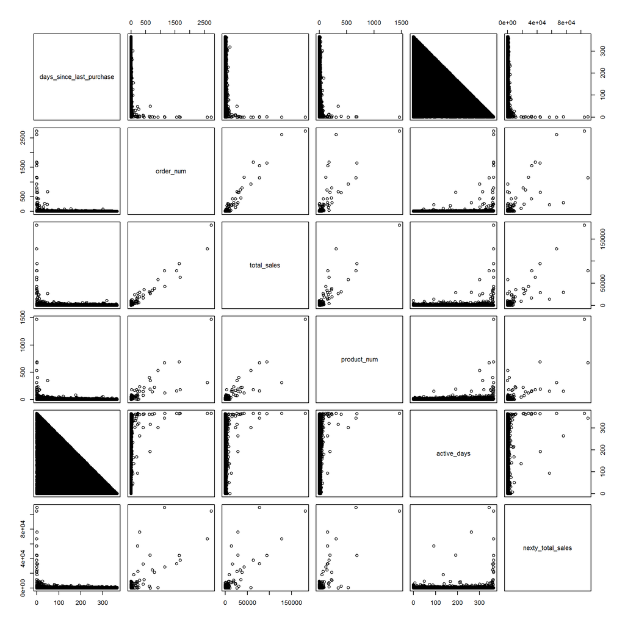

```r
pairs(all_customers_2012[, -1])
```

## Model fitting

Predict the spendings of customers in 2013 based on training set from 2012 For the first run, we won’t scale or clean the features and use them all

### Create train and test set

```r
set.seed(3456)
trainIndex <- createDataPartition(all_customers_2012$nexty_total_sales, p = .8,
                                  list = FALSE,
                                  times = 1)

customer_purchase_train <- all_customers_2012[ trainIndex,]
customer_purchase_test  <- all_customers_2012[-trainIndex,]
```

### Try some models

- Gradient boosting
- Linear regression
- Multivariate adaptive regression spline

```r
target_param = "nexty_total_sales"

ctrl <- trainControl(method = "repeatedcv",
                     number = 10,
                     repeats = 5)

# Boosting with trees
gbm_parameters <- ModelTrainingParameters(method = "gbm", ctrl = ctrl, tuning_grid = NULL)

# (Simple) Linear regression
lm_parameters <- ModelTrainingParameters(method = "lm", ctrl = ctrl, tuning_grid = NULL)

# Multivariate adaptive regression splines
mars_parameters <- ModelTrainingParameters(method = "earth", ctrl = ctrl, tuning_grid = NULL)


model_params <- list(ModelTrainingParameters())
model_params[[1]] <- lm_parameters
model_params[[2]] <- mars_parameters
model_params[[3]] <- gbm_parameters

fits <- trainMore(customer_purchase_train[, -c(1)], target_param, model_params)
```

```
## Fitting model:  lm  ... Fitting model:  earth  ... Fitting model:  gbm  ...
```

```r
summary(lm_fit <- fits[[1]])
```

```
##
## Call:
## lm(formula = .outcome ~ ., data = dat)
##
## Residuals:
##    Min     1Q Median     3Q    Max
## -30762    -21      4     16  62125
##
## Coefficients:
##                            Estimate Std. Error t value Pr(>|t|)
## (Intercept)              -26.352207   1.618125 -16.286  < 2e-16 ***
## days_since_last_purchase  -0.039196   0.007662  -5.115 3.13e-07 ***
## order_num                  8.137449   0.224611  36.229  < 2e-16 ***
## total_sales                0.406135   0.004212  96.428  < 2e-16 ***
## product_num               -0.463235   0.305128  -1.518    0.129
## active_days               -0.131641   0.013843  -9.510  < 2e-16 ***
## ---
## Signif. codes:  0 '***' 0.001 '**' 0.01 '*' 0.05 '.' 0.1 ' ' 1
##
## Residual standard error: 294.8 on 131157 degrees of freedom
## Multiple R-squared:  0.6545, Adjusted R-squared:  0.6545
## F-statistic: 4.97e+04 on 5 and 131157 DF,  p-value: < 2.2e-16
```

```r
summary(mars_fit <- fits[[2]])
```

```
## Call: earth(x=matrix[131163,5], y=c(13,2287,0,34,...), keepxy=TRUE,
##             degree=1, nprune=2)
##
##                        coefficients
## (Intercept)              21.0790228
## h(total_sales-1496.33)    0.5614543
##
## Selected 2 of 11 terms, and 1 of 5 predictors
## Termination condition: RSq changed by less than 0.001 at 11 terms
## Importance: total_sales, days_since_last_purchase-unused, ...
## Number of terms at each degree of interaction: 1 1 (additive model)
## GCV 84496.71    RSS 11082334970    GRSq 0.6641238    RSq 0.6641341
```

```r
summary(gbm_fit <- fits[[3]], plotit = F)
```

```
##                                               var    rel.inf
## total_sales                           total_sales 52.7161133
## product_num                           product_num 29.2444699
## order_num                               order_num 11.3774424
## active_days                           active_days  6.5103019
## days_since_last_purchase days_since_last_purchase  0.1516725
```

```r
results <- resamples(list(MARS = mars_fit,
                          LR = lm_fit,
                          GBM = gbm_fit))

summary(results)
```

```
##
## Call:
## summary.resamples(object = results)
##
## Models: MARS, LR, GBM
## Number of resamples: 50
##
## RMSE
##        Min. 1st Qu. Median  Mean 3rd Qu.  Max. NA's
## MARS  93.16   125.4  172.6 263.2   350.4 739.0    0
## LR   103.40   139.3  210.9 272.4   349.5 658.2    0
## GBM  104.80   181.1  304.1 329.8   415.8 877.9    0
##
## Rsquared
##          Min. 1st Qu. Median   Mean 3rd Qu.   Max. NA's
## MARS 0.002120  0.2297 0.6735 0.5583  0.8019 0.9753    0
## LR   0.011480  0.2239 0.5636 0.5261  0.7644 0.9820    0
## GBM  0.000793  0.2333 0.5591 0.4965  0.7258 0.9782    0
```

### Importance of features

We can see, that in all models, total_sales is the most important feature, in the lm model, order_num is the second, but in the gbm model, product_num is. In the mars model, only total_sales got used, all other features were reducted.

```r
lm_importance <- varImp(lm_fit, scale=FALSE)
lm_importance
```

```
## lm variable importance
##
##                          Overall
## total_sales               96.428
## order_num                 36.229
## active_days                9.510
## days_since_last_purchase   5.115
## product_num                1.518
```

```r
mars_importance <- varImp(mars_fit, scale=FALSE)
mars_importance
```

```
## earth variable importance
##
##                          Overall
## total_sales                  100
## active_days                    0
## product_num                    0
## days_since_last_purchase       0
## order_num                      0
```

```r
gbm_importance <- varImp(gbm_fit, scale=FALSE)
gbm_importance
```

```
## gbm variable importance
##
##                            Overall
## total_sales              4.674e+10
## product_num              2.593e+10
## order_num                1.009e+10
## active_days              5.772e+09
## days_since_last_purchase 1.345e+08
```

### Test

##### Boosting with trees

```r
gbm_pred <- testNextYearsSales(gbm_fit, customer_purchase_test)
```

```
##
## Method: gbm
## Prediction MSE: 226269.5 , prediciton RMSE: 475.6779
```

```r
gbm_RMSE <- gbm_pred$gbm.RMSE
gbm_total_diff <- sum(gbm_pred$gbm.prediction - customer_purchase_test$nexty_total_sales)
gbm_total_diff_perc <- gbm_total_diff * 100 / sum(customer_purchase_test$nexty_total_sales)
```

##### (Simple) Linear regression

```r
lm_pred <- testNextYearsSales(lm_fit, customer_purchase_test)
```

```
##
## Method: lm
## Prediction MSE: 161153.5 , prediciton RMSE: 401.4393
```

```r
lm_RMSE <- lm_pred$lm.RMSE
lm_total_diff <- sum(lm_pred$lm.prediction - customer_purchase_test$nexty_total_sales)
lm_total_diff_perc <- lm_total_diff * 100 / sum(customer_purchase_test$nexty_total_sales)
print(paste("RMSE:", lm_RMSE, ", Total difference:", lm_total_diff, ", difference(%):", lm_total_diff_perc))
```

```
## [1] "RMSE: 401.439274060469 , Total difference: -38701.1420654992 , difference(%): -4.09338351216846"
```

##### Mars

```r
mars_pred <- testNextYearsSales(mars_fit, customer_purchase_test)
```

```
##
## Method: earth
## Prediction MSE: 150524.5 , prediciton RMSE: 387.9749
```

```r
mars_RMSE <- mars_pred$earth.RMSE
mars_total_diff <- sum(mars_pred$earth.prediction - customer_purchase_test$nexty_total_sales)
mars_total_diff_perc <- mars_total_diff * 100 / sum(customer_purchase_test$nexty_total_sales)
print(paste("RMSE:", mars_RMSE, ", Total difference:", mars_total_diff, ", difference(%):", mars_total_diff_perc))
```

```
## [1] "RMSE: 387.97486837894 , Total difference: -36122.4194973754 , difference(%): -3.82063444380893"
```

### Train for whole 2012 dataset and test customer groups

- dec_customers: customers who purchased in december
- onetime_customers: customers with only 1 order

```r
final_fits <- trainMore(all_customers_2012[, -c(1)], target_param, model_params)
```

```
## Fitting model:  lm  ... Fitting model:  earth  ... Fitting model:  gbm  ...
```

```r
# Linear regression
final_lm_fit <- final_fits[[1]]
summary(final_lm_fit)
```

```
##
## Call:
## lm(formula = .outcome ~ ., data = dat)
##
## Residuals:
##    Min     1Q Median     3Q    Max
## -35976    -21      8     21  62320
##
## Coefficients:
##                            Estimate Std. Error t value Pr(>|t|)
## (Intercept)              -45.394421   1.543341 -29.413  < 2e-16 ***
## days_since_last_purchase  -0.025408   0.007321  -3.471 0.000519 ***
## order_num                  6.297647   0.193081  32.617  < 2e-16 ***
## total_sales                0.398211   0.003988  99.841  < 2e-16 ***
## product_num               13.525452   0.283838  47.652  < 2e-16 ***
## active_days               -0.341560   0.013176 -25.923  < 2e-16 ***
## ---
## Signif. codes:  0 '***' 0.001 '**' 0.01 '*' 0.05 '.' 0.1 ' ' 1
##
## Residual standard error: 314.5 on 163947 degrees of freedom
## Multiple R-squared:  0.6708, Adjusted R-squared:  0.6708
## F-statistic: 6.682e+04 on 5 and 163947 DF,  p-value: < 2.2e-16
```

```r
# Mars
final_mars_fit <- final_fits[[2]]
summary(final_mars_fit)
```

```
## Call: earth(x=matrix[163953,5], y=c(13,0,2287,0,3...), keepxy=TRUE,
##             degree=1, nprune=2)
##
##                        coefficients
## (Intercept)              21.0975363
## h(total_sales-1735.95)    0.6186358
##
## Selected 2 of 11 terms, and 1 of 5 predictors
## Termination condition: RSq changed by less than 0.001 at 11 terms
## Importance: total_sales, days_since_last_purchase-unused, ...
## Number of terms at each degree of interaction: 1 1 (additive model)
## GCV 96180.49    RSS 15768503313    GRSq 0.6799929    RSq 0.6800007
```

```r
# Gbm
final_gbm_fit <- final_fits[[3]]
summary(final_gbm_fit)
```

```
##                                               var  rel.inf
## total_sales                           total_sales 43.42669
## order_num                               order_num 29.90262
## product_num                           product_num 22.68582
## active_days                           active_days  3.98488
## days_since_last_purchase days_since_last_purchase  0.00000
```

Filter customers, who purchased in december and customers, who only ordered once

```r
dec_customer_ids <- purchases %>%
  filter(year(purchase_date) == 2012 & month(purchase_date)  ==  12) %>%
  dplyr::select(contact_id) %>%
  unique

dec_customers <- all_customers_2012 %>%
  filter(contact_id %in% dec_customer_ids$contact_id)

onetime_customers <- all_customers_2012 %>%
  filter(order_num == 1)
```

##### Gbm

```r
# December customers
gbm_pred_dec <- testNextYearsSales(final_gbm_fit, dec_customers)
```

```r
gbm_dec_RMSE <- gbm_pred_dec$gbm.RMSE
gbm_dec_total_diff <- sum(gbm_pred_dec$gbm.prediction - dec_customers$nexty_total_sales)
gbm_dec_total_diff_perc <- gbm_dec_total_diff * 100 / sum(dec_customers$nexty_total_sales)
print(paste("RMSE:", gbm_dec_RMSE, ", Total difference:", gbm_dec_total_diff, ", difference(%):", gbm_dec_total_diff_perc))
```

```
## [1] "RMSE: 936.07666922772 , Total difference: -480169.595311194 , difference(%): -27.7206898480033"
```

```r
# Onetime customers
gbm_pred_onetime <- testNextYearsSales(final_gbm_fit, onetime_customers)
```

```r
gbm_onetime_RMSE <- gbm_pred_onetime$gbm.RMSE
gbm_onetime_total_diff <- sum(gbm_pred_onetime$gbm.prediction - onetime_customers$nexty_total_sales)
gbm_onetime_total_diff_perc <- gbm_onetime_total_diff * 100 / sum(onetime_customers$nexty_total_sales)
print(paste("RMSE:", gbm_onetime_RMSE, ", Total difference:", gbm_onetime_total_diff, ", difference(%):", gbm_onetime_total_diff_perc))
```

```
## [1] "RMSE: 63.3031693493983 , Total difference: 1297658.60838485 , difference(%): 85.2004248079413"
```

##### Lm

```r
# December customers
lm_pred_dec <- testNextYearsSales(final_lm_fit, dec_customers)
```

```r
lm_dec_RMSE <- lm_pred_dec$lm.RMSE
lm_dec_total_diff <- sum(lm_pred_dec$lm.prediction - dec_customers$nexty_total_sales)
lm_dec_total_diff_perc <- lm_dec_total_diff * 100 / sum(dec_customers$nexty_total_sales)
print(paste("RMSE:", lm_dec_RMSE, ", Total difference:", lm_dec_total_diff, ", difference(%):", lm_dec_total_diff_perc))
```

```
## [1] "RMSE: 805.525542570583 , Total difference: -144413.464917658 , difference(%): -8.33713943979196"
```

```r
# Onetime customers
lm_pred_onetime <- testNextYearsSales(final_lm_fit, onetime_customers)
```

```r
lm_onetime_RMSE <- lm_pred_onetime$lm.RMSE
lm_onetime_total_diff <- sum(lm_pred_onetime$lm.prediction - onetime_customers$nexty_total_sales)
lm_onetime_total_diff_perc <- lm_onetime_total_diff * 100 / sum(onetime_customers$nexty_total_sales)
print(paste("RMSE:", lm_onetime_RMSE, ", Total difference:", lm_onetime_total_diff, ", difference(%):", lm_onetime_total_diff_perc))
```

```
## [1] "RMSE: 78.2540139770477 , Total difference: -472295.976085233 , difference(%): -31.009556394519"
```

##### Mars

```r
# December customers
mars_pred_dec <- testNextYearsSales(final_mars_fit, dec_customers)
```

```r
mars_dec_RMSE <- mars_pred_dec$earth.RMSE
mars_dec_total_diff <- sum(mars_pred_dec$earth.prediction - dec_customers$nexty_total_sales)
mars_dec_total_diff_perc <- mars_dec_total_diff * 100 / sum(dec_customers$nexty_total_sales)
print(paste("RMSE:", mars_dec_RMSE, ", Total difference:", mars_dec_total_diff, ", difference(%):", mars_dec_total_diff_perc))
```

```
## [1] "RMSE: 808.182253590723 , Total difference: -524188.008212756 , difference(%): -30.2619185796033"
```

```r
# Onetime customers
mars_pred_onetime <- testNextYearsSales(final_mars_fit, onetime_customers)
```

```r
mars_onetime_RMSE <- mars_pred_onetime$earth.RMSE
mars_onetime_total_diff <- sum(mars_pred_onetime$earth.prediction - onetime_customers$nexty_total_sales)
mars_onetime_total_diff_perc <- mars_onetime_total_diff * 100 / sum(onetime_customers$nexty_total_sales)
print(paste("RMSE:", mars_onetime_RMSE, ", Total difference:", mars_onetime_total_diff, ", difference(%):", mars_onetime_total_diff_perc))
```

```
## [1] "RMSE: 65.6210897151422 , Total difference: 1290429.80632496 , difference(%): 84.7258030527463"
```

We can see, that non of the models is precise enough

1. Do we need to separate customers?
   - Maybe group customers by the RFM features to get a more precise prediction and train each group independently
2. Scale data and/or remove/add some features and try to fit again
3. Do we need an extra model, separate from customer features?
   - Unfortunatelly forecasting won’t work in this case, because seasonability is mainly in yearly data and we only have 2 years of data (2 periods), so can’t test it.

## Customer grouping / Clustering with scaled data

Does adding cluster groups help?

Let’s log transform first to reduce skewness and plot again the transformed RFMs We can see, that the total_sales_amount is appr. gaussian.. so should the nexty_total_sales be, so maybe we can try glm fitting too (later)

```r
all_customers_2012_scaled <- cbind(contact_id = all_customers_2012[, 1], logTransformation(all_customers_2012[, -1], exp(1), 1))
summary(all_customers_2012_scaled[, c(-1, -7)])
```

```
##  days_since_last_purchase   order_num       total_sales
##  Min.   :0.000            Min.   :0.6931   Min.   : 0.000
##  1st Qu.:4.078            1st Qu.:0.6931   1st Qu.: 3.525
##  Median :5.063            Median :0.6931   Median : 4.188
##  Mean   :4.729            Mean   :0.8110   Mean   : 4.250
##  3rd Qu.:5.557            3rd Qu.:0.6931   3rd Qu.: 4.890
##  Max.   :5.903            Max.   :7.9128   Max.   :12.108
##   product_num      active_days
##  Min.   :0.6931   Min.   :0.0000
##  1st Qu.:0.6931   1st Qu.:0.0000
##  Median :0.6931   Median :0.0000
##  Mean   :0.9108   Mean   :0.8025
##  3rd Qu.:1.0986   3rd Qu.:0.0000
##  Max.   :7.2930   Max.   :5.9026
```

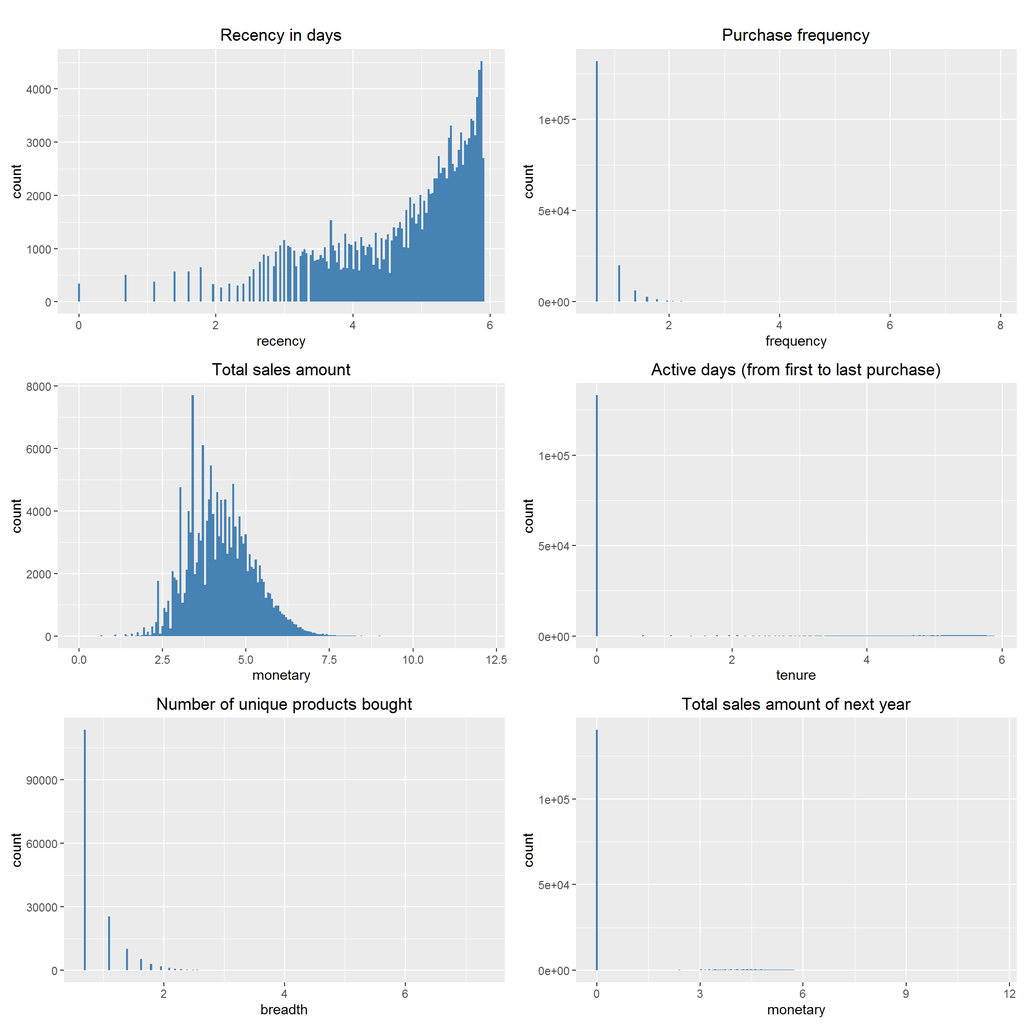

```r
plotRfms(all_customers_2012_scaled, c(200, 200, 200, 200, 200, 200), "rfmtbn")
```

### Determine number of cluster

From the plot, we can see, that it converged around 11 , but there was a break at 2 and 3 clusters too

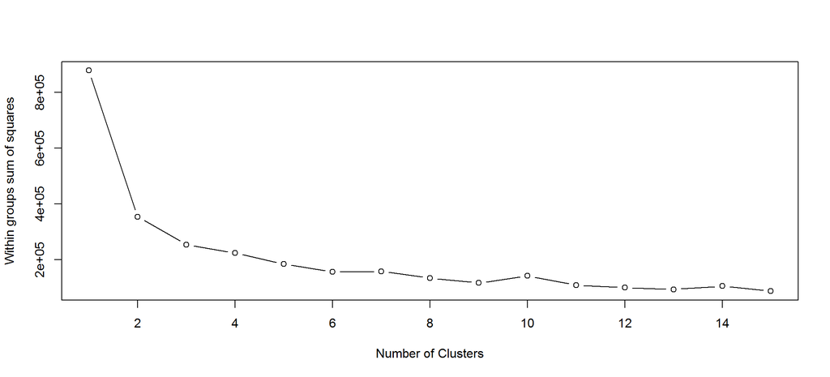

```r
set.seed(25)
plotSoSByClusterNum(all_customers_2012_scaled[, c(-1, -7)])
```

If we fit to 11 groups, we maybe won’t have enough data for training each group, so we will try splitting customers into 2 groups only From the 2 cluster groups, we can see, that:

- There is one group, which has high total_sales, active_days and order_num and a low days_since_last_purchase. In other words it has high monetary, tenure, frequency and high recency, so these are the “best customers”
- There is one group with every RFM being much lower, except the recency, these can be maybe the one-time customers

```r
customer_groups <- fitCluster(all_customers_2012_scaled[, c(-1, -7)], 2)
```

```
##   Group.1 days_since_last_purchase order_num total_sales product_num
## 1       1                 4.287155  1.321594    5.163610   1.4894014
## 2       2                 4.820581  0.704866    4.060095   0.7904884
##   active_days
## 1  4.51344546
## 2  0.03110149
```

Add grouping to customer data and separate them by cluster group

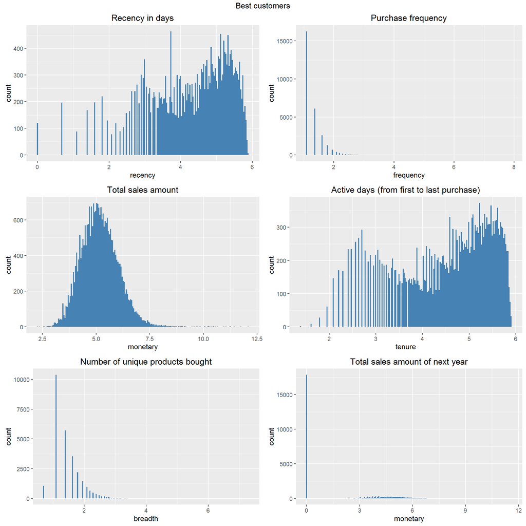

```r
all_customers_2012_grouped <- data.frame(all_customers_2012_scaled, cluster = as.factor(customer_groups$cluster))
best_2012 <- all_customers_2012_grouped %>%
  filter(cluster == "1") %>%
  dplyr::select(-cluster)
plotRfms(best_2012, c(200, 200, 200, 200, 200, 200), "rfmtbn", title = "Best customers")
```

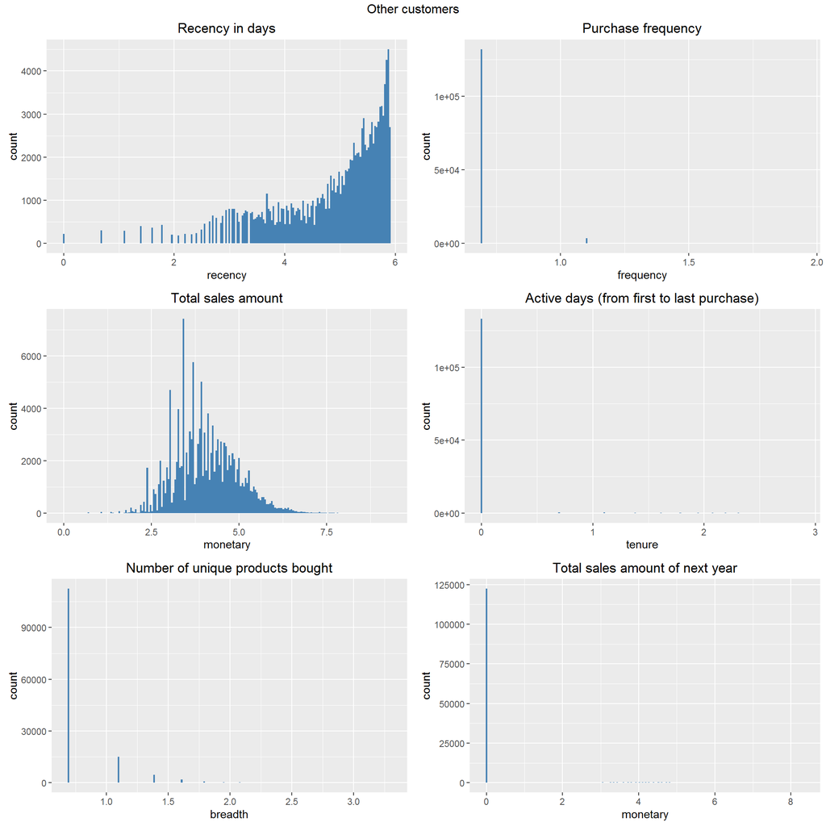

```r
other_2012 <- all_customers_2012_grouped %>%
  filter(cluster == "2") %>%
  dplyr::select(-cluster)
plotRfms(other_2012, c(200, 200, 200, 200, 200, 200), "rfmtbn", title = "Other customers")
```

### Train and test each group

We will calculate RMSE with rescaled data

#### Best customers

```r
best_2012_outcome <- trainAndTestMore(model_params, "nexty_total_sales", best_2012[, -1])
```

```
## Fitting model:  lm  ... Fitting model:  earth  ... Fitting model:  gbm  ...
```

```r
best_2012_pred_lm <- reverseLogTransformation(best_2012_outcome$predictions[[1]]$lm.prediction, exp(1), 1)$data
best_2012_pred_mars <- reverseLogTransformation(best_2012_outcome$predictions[[2]]$earth.prediction[, 1], exp(1), 1)$data
best_2012_pred_gbm <- reverseLogTransformation(best_2012_outcome$predictions[[3]]$gbm.prediction, exp(1), 1)$data
best_2012_actual <- reverseLogTransformation(data.frame(best_2012_outcome$actual), exp(1), 1)
```

##### Lr

```r
print(best_2012_RMSE_lm <- calculateRMSE(best_2012_pred_lm, best_2012_actual))
```

```
## [1] 23065.16
```

```r
print(best_2012_pred_diff_lm <- sum(best_2012_pred_lm - best_2012_actual))
```

```
## [1] 2907724
```

```r
print(best_2012_pred_diff_perc_lm <- best_2012_pred_diff_lm * 100 / sum(best_2012_actual))
```

```
## [1] 494.0674
```

##### Gbm

```r
print(best_2012_RMSE_gbm <- calculateRMSE(best_2012_pred_gbm, best_2012_actual))
```

```
## [1] 1075.946
```

```r
print(best_2012_pred_diff_gbm <- sum(best_2012_pred_gbm - best_2012_actual))
```

```
## [1] -493255.3
```

```r
print(best_2012_pred_diff_perc_gbm <- best_2012_pred_diff_gbm * 100 / sum(best_2012_actual))
```

```
## [1] -83.81173
```

##### Mars

```r
print(best_2012_RMSE_mars <- calculateRMSE(best_2012_pred_mars, best_2012_actual))
```

```
## [1] 444.392
```

```r
print(best_2012_pred_diff_mars <- sum(best_2012_pred_mars - best_2012_actual))
```

```
## [1] -303929.8
```

```r
print(best_2012_pred_diff_perc_mars <- best_2012_pred_diff_mars * 100 / sum(best_2012_actual))
```

```
## [1] -51.64239
```

#### Other customers

```r
other_2012_outcome <- trainAndTestMore(model_params, "nexty_total_sales", other_2012[, -1])
```

```
## Fitting model:  lm  ... Fitting model:  earth  ... Fitting model:  gbm  ...
```

```r
other_2012_pred_lm <- reverseLogTransformation(other_2012_outcome$predictions[[1]]$lm.prediction, exp(1), 1)$data
other_2012_pred_mars <- reverseLogTransformation(other_2012_outcome$predictions[[2]]$earth.prediction[, 1], exp(1), 1)$data
other_2012_pred_gbm <- reverseLogTransformation(other_2012_outcome$predictions[[3]]$gbm.prediction, exp(1), 1)$data
other_2012_actual <- reverseLogTransformation(data.frame(other_2012_outcome$actual), exp(1), 1)
```

##### Lr

```r
print(other_2012_RMSE_lm <- calculateRMSE(other_2012_pred_lm, other_2012_actual))
```

```
## [1] 67.68882
```

```r
print(other_2012_pred_diff_lm <- sum(other_2012_pred_lm - other_2012_actual))
```

```
## [1] -321200.4
```

```r
print(other_2012_pred_diff_perc_lm <- other_2012_pred_diff_lm * 100 / sum(other_2012_actual))
```

```
## [1] -95.67797
```

##### Gbm

```r
print(other_2012_RMSE_gbm <- calculateRMSE(other_2012_pred_gbm, other_2012_actual))
```

```
## [1] 67.6828
```

```r
print(other_2012_pred_diff_gbm <- sum(other_2012_pred_gbm - other_2012_actual))
```

```
## [1] -321171
```

```r
print(other_2012_pred_diff_perc_gbm <- other_2012_pred_diff_gbm * 100 / sum(other_2012_actual))
```

```
## [1] -95.6692
```

##### Mars

```r
print(other_2012_RMSE_mars <- calculateRMSE(other_2012_pred_mars, other_2012_actual))
```

```
## [1] 67.68993
```

```r
print(other_2012_pred_diff_mars <- sum(other_2012_pred_mars - other_2012_actual))
```

```
## [1] -321196.9
```

```r
print(other_2012_pred_diff_perc_mars <- other_2012_pred_diff_mars * 100 / sum(other_2012_actual))
```

```
## [1] -95.67693
```

Customer grouping and scaling didn’t help much, but we could see, that order_num, product_num and total_sales are appr. linear, and the log transformation helped the skewness of total_sales, so a gaussian linear model with log link could be a good choise

Save the customer RFMs by year and the model and test results for later

```r
write.csv(customer_rfm_2012, "data/RFM_2012.csv", row.names = F)
write.csv(customer_rfm_2013, "data/RFM_2013.csv", row.names = F)
```

Save training and test results

```r
lm_results <- createModelSummary(description = "Linear regression, no scale, no transform, cross validated, formula = nexty_total_sales ~ order_num + product_num + total_sales + days_since_last_purchase + active_days",
                                 test_RMSE = lm_RMSE,
                                 test_diff = lm_total_diff,
                                 test_diff_percent = lm_total_diff_perc,
                                 dec_test_RMSE = lm_dec_RMSE,
                                 dec_test_diff = lm_dec_total_diff,
                                 dec_test_diff_percent = lm_dec_total_diff_perc,
                                 onetime_test_RMSE = lm_onetime_RMSE,
                                 onetime_test_diff = lm_onetime_total_diff,
                                 onetime_test_diff_percent = lm_onetime_total_diff_perc)
saveRDS(lm_results, file = "data/results/lm.rds")

gbm_results <- createModelSummary(description = "Gradient boosting, no scale, no transform, cross validated, formula = nexty_total_sales ~ order_num + product_num + total_sales + days_since_last_purchase + active_days",
                                 test_RMSE = gbm_RMSE,
                                 test_diff = gbm_total_diff,
                                 test_diff_percent = gbm_total_diff_perc,
                                 dec_test_RMSE = gbm_dec_RMSE,
                                 dec_test_diff = gbm_dec_total_diff,
                                 dec_test_diff_percent = gbm_dec_total_diff_perc,
                                 onetime_test_RMSE = gbm_onetime_RMSE,
                                 onetime_test_diff = gbm_onetime_total_diff,
                                 onetime_test_diff_percent = gbm_onetime_total_diff_perc)
```

```r
saveRDS(gbm_results, file = "data/results/gbm.rds")

mars_results <- createModelSummary(description = "Multivariet adaptive regression spline, no scale, no transform, cross validated, formula = nexty_total_sales ~ order_num + product_num + total_sales + days_since_last_purchase + active_days",
                                  test_RMSE = mars_dec_RMSE,
                                  test_diff = mars_total_diff,
                                  test_diff_percent = mars_total_diff_perc,
                                  dec_test_RMSE = mars_dec_RMSE,
                                  dec_test_diff = mars_dec_total_diff,
                                  dec_test_diff_percent = mars_dec_total_diff_perc,
                                  onetime_test_RMSE = mars_onetime_RMSE,
                                  onetime_test_diff = mars_onetime_total_diff,
                                  onetime_test_diff_percent = mars_onetime_total_diff_perc)
saveRDS(mars_results, file = "data/results/mars.rds")

bestc_lm_results <- createModelSummary(description = "Linear regression for \"best customers\", no scale, log transformation for both dependent and independent variables, cross validated, formula = nexty_total_sales ~ order_num + product_num + total_sales + days_since_last_purchase + active_days",
                                      test_RMSE = best_2012_RMSE_lm,
                                      test_diff = best_2012_pred_diff_lm,
                                      test_diff_percent = best_2012_pred_diff_perc_lm)
saveRDS(bestc_lm_results, file = "data/results/bestc_lm.rds")

bestc_gbm_results <- createModelSummary(description = "Gradient boosting for \"best customers\", no scale, log transformation for both dependent and independent variables, cross validated, formula = nexty_total_sales ~ order_num + product_num + total_sales + days_since_last_purchase + active_days",
                                       test_RMSE = best_2012_RMSE_gbm,
                                       test_diff = best_2012_pred_diff_gbm,
                                       test_diff_percent = best_2012_pred_diff_perc_gbm)
```

```r
saveRDS(bestc_gbm_results, file = "data/results/bestc_gbm.rds")

bestc_mars_results <- createModelSummary(description = "Multivariet adaptive regression spline for \"best customers\", no scale, log transformation for both dependent and independent variables, cross validated, formula = nexty_total_sales ~ order_num + product_num + total_sales + days_since_last_purchase + active_days",
                                       test_RMSE = best_2012_RMSE_mars,
                                       test_diff = best_2012_pred_diff_mars,
                                       test_diff_percent = best_2012_pred_diff_perc_mars)
saveRDS(bestc_mars_results, file = "data/results/bestc_mars.rds")

otherc_lm_results <- createModelSummary(description = "Linear regression for \"other customers\", no scale, log transformation for both dependent and independent variables, cross validated, formula = nexty_total_sales ~ order_num + product_num + total_sales + days_since_last_purchase + active_days",
                                       test_RMSE = other_2012_RMSE_lm,
                                       test_diff = other_2012_pred_diff_lm,
                                       test_diff_percent = other_2012_pred_diff_perc_lm)
saveRDS(otherc_lm_results, file = "data/results/otherc_lm.rds")

otherc_gbm_results <- createModelSummary(description = "Gradient boosting for \"other customers\", no scale, log transformation for both dependent and independent variables, cross validated, formula = nexty_total_sales ~ order_num + product_num + total_sales + days_since_last_purchase + active_days",
                                        test_RMSE = other_2012_RMSE_gbm,
                                        test_diff = other_2012_pred_diff_gbm,
                                        test_diff_percent = other_2012_pred_diff_perc_gbm)
```

```r
saveRDS(otherc_gbm_results, file = "data/results/otherc_gbm.rds")

otherc_mars_results <- createModelSummary(description = "Multivariet adaptive regression spline for \"other customers\", no scale, log transformation for both dependent and independent variables, cross validated, formula = nexty_total_sales ~ order_num + product_num + total_sales + days_since_last_purchase + active_days",
                                         test_RMSE = other_2012_RMSE_mars,
                                         test_diff = other_2012_pred_diff_mars,
                                         test_diff_percent = other_2012_pred_diff_perc_mars)
saveRDS(otherc_mars_results, file = "data/results/otherc_mars.rds")
```